# week-9

Viki-Misi

November 19, 2021

```r
df <- readRDS('data.rds')
```

#### `Awards`

This will be the difficult part.

As a first step create 4 new columns:

- wins
- nominations
- oscars
- oscar nominations

Create 4 functions to extract the number from the text in the `awards` column.

**Hint 1**

Use `grepl()` to determine if the word *wins/nominations.|nomination./Won&Oscar/Nominated&Oscar* are in the text.

**Hint 2**

Use `strsplit()` to create a list of the words.

**Hint 3**

Make sure you deal with *wins.* vs *wins* or *nominations.* vs *nomination.*.

**Hint 4**

Use `which()` to find on which place the searched word (*wins/nominations./Won/Nominated*) is, and return the value from the list before this. In case the searched word is not in the sentence return NA.

Loop through the rows of the data frame and get the number of wins and nominations in the 4 predefined columns using the functions created.

### Nice jooob, you are done with cleaning

You can now cheer a bit :D

## Save the cleaned file

Last step is always to save the cleaned data in a format (csv, rds) that is useful later.

# Data.table

We will look at data.table package.

For this the first step is to transfer the data frame to a data.table format.

```r
df <- data.table(df)
```

Alternatively you can read your data with `fread()` instead of `read.csv()` or `read_csv()`

## Filter rows

You can filter rows by their number. This gives the first 5 rows of the df.

```r
dim(df[1:5])
```

```
## [1]  5 30
```

You can add a , after the number to make sure you filter for rows. If you do so for a data frame that is not a data.table, this makes sure that you filter for rows, if you do not include, it will filter for columns.

```r
dim(df[1:5])
```

```
## [1]  5 30
```

```r
dim(df[1:5,])
```

```
## [1]  5 30
```

The power of data.table lies in the ease of filtering and arranging and calculating new values.

First lets talk about filtering. Instead of including numbers you can filter by setting the values. For example this will filter the data frame to only the rows where the length of the film is more than 160 minutes.

```r
df[length_min > 160][1:10,1:5] %>% kbl()
```

| imdb_rank | title | year | rated | released |
| --- | --- | --- | --- | --- |
| 2 | The Godfather | 1972 | R | 1972-03-24 |
| 3 | The Godfather: Part II | 1974 | R | 1974-12-20 |
| 6 | Schindler's List | 1993 | R | 1994-02-04 |
| 7 | The Lord of the Rings: The Return of the King | 2003 | PG-13 | 2003-12-17 |
| 10 | The Lord of the Rings: The Fellowship of the Ring | 2001 | PG-13 | 2001-12-19 |
| 14 | The Lord of the Rings: The Two Towers | 2002 | PG-13 | 2002-12-18 |
| 24 | Saving Private Ryan | 1998 | R | 1998-07-24 |
| 26 | Interstellar | 2014 | PG-13 | 2014-11-07 |
| 30 | The Green Mile | 1999 | R | 1999-12-10 |
| 49 | Django Unchained | 2012 | R | 2012-12-25 |

You can chain your filters by **&** or **|**.

```r
df[length_min > 160 & metascore < 90][,1:5] %>% kbl()
```

| imdb_rank | title | year | rated | released |
| --- | --- | --- | --- | --- |
| 3 | The Godfather: Part II | 1974 | R | 1974-12-20 |
| 14 | The Lord of the Rings: The Two Towers | 2002 | PG-13 | 2002-12-18 |
| 26 | Interstellar | 2014 | PG-13 | 2014-11-07 |
| 30 | The Green Mile | 1999 | R | 1999-12-10 |
| 49 | Django Unchained | 2012 | R | 2012-12-25 |
| 52 | The Dark Knight Rises | 2012 | PG-13 | 2012-07-20 |
| 61 | Braveheart | 1995 | R | 1995-05-24 |
| 84 | Scarface | 1983 | R | 1983-12-09 |
| 97 | Heat | 1995 | R | 1995-12-15 |
| 111 | Casino | 1995 | R | 1995-11-22 |
| 116 | The Wolf of Wall Street | 2013 | R | 2013-12-25 |
| 123 | The Deer Hunter | 1978 | R | 1979-02-23 |
| 153 | The Legend of 1900 | 1998 | R | 1998-10-28 |
| 10 | Dogville | 2003 | R | 2004-04-23 |
| 33 | JFK | 1991 | R | 1991-12-20 |
| 36 | Magnolia | 1999 | R | 2000-01-07 |

#### Task 1

Filter your data frame for only the films that were released after 2000 and their rating is above 8.5.

| imdb_rank | title | year | rated | released |
| --- | --- | --- | --- | --- |
| 4 | The Dark Knight | 2008 | PG-13 | 2008-07-18 |
| 7 | The Lord of the Rings: The Return of the King | 2003 | PG-13 | 2003-12-17 |
| 10 | The Lord of the Rings: The Fellowship of the Ring | 2001 | PG-13 | 2001-12-19 |
| 13 | Inception | 2010 | PG-13 | 2010-07-16 |
| 14 | The Lord of the Rings: The Two Towers | 2002 | PG-13 | 2002-12-18 |
| 26 | Interstellar | 2014 | PG-13 | 2014-11-07 |

#### Task 2

Lets look at the ones that are not from the USA, won any Oscars or had any Oscar nominations.

| imdb_rank | title | year | rated | released |
| --- | --- | --- | --- | --- |
| 10 | The Lord of the Rings: The Fellowship of the Ring | 2001 | PG-13 | 2001-12-19 |
| 33 | The Pianist | 2002 | R | 2003-03-28 |
| 46 | Alien | 1979 | R | 1979-06-22 |
| 65 | Lawrence of Arabia | 1962 | PG | 1962-12-11 |
| 67 | A Clockwork Orange | 1971 | R | 1972-02-02 |
| 75 | 2001: A Space Odyssey | 1968 | G | 1968-05-12 |
| 76 | Full Metal Jacket | 1987 | R | 1987-07-10 |
| 92 | The Third Man | 1949 | APPROVED | 1949-08-31 |
| 105 | The Bridge on the River Kwai | 1957 | PG | 1957-12-14 |
| 106 | Room | 2015 | R | 2016-01-22 |
| 111 | Casino | 1995 | R | 1995-11-22 |
| 118 | Hacksaw Ridge | 2016 | R | 2016-11-04 |
| 122 | Trainspotting | 1996 | R | 1996-08-09 |
| 142 | In the Name of the Father | 1993 | R | 1994-02-25 |
| 144 | Hotel Rwanda | 2004 | PG-13 | 2005-02-04 |
| 145 | Platoon | 1986 | R | 1987-02-06 |
| 146 | Song of the Sea | 2014 | PG | 2014-12-10 |
| 155 | Brief Encounter | 1945 | NOT RATED | 1946-08-24 |
| 160 | Mad Max: Fury Road | 2015 | R | 2015-05-15 |
| 173 | Gandhi | 1982 | PG | 1983-02-25 |
| 174 | Barry Lyndon | 1975 | PG | 1975-12-18 |
| 186 | Sleuth | 1972 | PG | 1973-07-12 |
| 198 | Lion | 2016 | PG-13 | 2017-01-06 |
| 7 | The Imitation Game | 2014 | PG-13 | 2014-12-25 |
| 13 | Papillon | 1973 | R | 1974-02-06 |
| 30 | The King's Speech | 2010 | R | 2010-12-25 |
| 33 | JFK | 1991 | R | 1991-12-20 |
| 35 | Blood Diamond | 2006 | R | 2006-12-08 |
| 38 | The Revenant | 2015 | R | 2016-01-08 |
| 49 | The Straight Story | 1999 | G | 1999-11-03 |
| 50 | Slumdog Millionaire | 2008 | R | 2008-12-25 |

#### Task 3

Now filter for the ones that are adventure from the Warner Brothers and we have box office info for them.

| imdb_rank | title | year | rated | released |
| --- | --- | --- | --- | --- |
| 13 | Inception | 2010 | PG-13 | 2010-07-16 |
| 75 | 2001: A Space Odyssey | 1968 | G | 1968-05-12 |
| 90 | Batman Begins | 2005 | PG-13 | 2005-06-15 |
| 160 | Mad Max: Fury Road | 2015 | R | 2015-05-15 |
| 169 | Harry Potter and the Deathly Hallows: Part 2 | 2011 | PG-13 | 2011-07-15 |
| 185 | The Wizard of Oz | 1939 | G | 1939-08-25 |
| 35 | Blood Diamond | 2006 | R | 2006-12-08 |

## Select or calculate columns

`df[filter, select or calculate,...]`

As the second variable for in the [] you can select given columns from the data. You have to use `list()` or `.()`.

```r
df[1:10, list(title, length_min, ratings_value)] %>%
  kbl()
```

| title | length_min | ratings_value |
| --- | --- | --- |
| The Shawshank Redemption | 142 | 9.3 |
| The Godfather | 175 | 9.2 |
| The Godfather: Part II | 202 | 9.0 |
| The Dark Knight | 152 | 9.0 |
| 12 Angry Men | 96 | 8.9 |
| Schindler's List | 195 | 8.9 |
| The Lord of the Rings: The Return of the King | 201 | 8.9 |
| Pulp Fiction | 154 | 8.9 |
| Fight Club | 139 | 8.8 |
| The Lord of the Rings: The Fellowship of the Ring | 178 | 8.8 |

You can also rename the columns like:

```r
df[1:10, .('Film title' = title,
              'Length of the movie' = length_min,
              'IMDB Rating' = ratings_value)] %>%
  kbl()
```

| Film title | Length of the movie | IMDB Rating |
| --- | --- | --- |
| The Shawshank Redemption | 142 | 9.3 |
| The Godfather | 175 | 9.2 |
| The Godfather: Part II | 202 | 9.0 |
| The Dark Knight | 152 | 9.0 |
| 12 Angry Men | 96 | 8.9 |
| Schindler's List | 195 | 8.9 |
| The Lord of the Rings: The Return of the King | 201 | 8.9 |
| Pulp Fiction | 154 | 8.9 |
| Fight Club | 139 | 8.8 |
| The Lord of the Rings: The Fellowship of the Ring | 178 | 8.8 |

With using the `order()` function you can also reorder the values based on the values in one column.

```r
df[1:10, list('Film title' = title,
              'Length of the movie' = length_min,
              'IMDB Rating' = ratings_value)][order(-`Length of the movie`)] %>%
  kbl()
```

| Film title | Length of the movie | IMDB Rating |
| --- | --- | --- |
| The Godfather: Part II | 202 | 9.0 |
| The Lord of the Rings: The Return of the King | 201 | 8.9 |
| Schindler's List | 195 | 8.9 |
| The Lord of the Rings: The Fellowship of the Ring | 178 | 8.8 |
| The Godfather | 175 | 9.2 |
| Pulp Fiction | 154 | 8.9 |
| The Dark Knight | 152 | 9.0 |
| The Shawshank Redemption | 142 | 9.3 |
| Fight Club | 139 | 8.8 |
| 12 Angry Men | 96 | 8.9 |

The most cool thing here is that you can really easily calculate stuff here. It can be one value.

The number of films that are longer than 160 minutes.

```r
df[length_min > 160, .N]
```

```
## [1] 33
```

Or the mean rating for these.

```r
df[length_min > 160, mean(ratings_value)]
```

```
## [1] 8.363636
```

#### Task 4

Calculate the mean length of the films that were produced between 1990 and 2000 and has won an award.

```
## [1] 128.5
```

#### Task 5

Calculate the minimum, maximum and the mean box office revenue for films with more than 1000000 imbd votes and are rating R.

| min | max | mean |
| --- | --- | --- |
| 162804648 | 162804648 | 162804648 |

#### Task 6

Calcutale the total number of nominations the films receiced thats name was longer then 15 charachters.

```
## [1] 4505
```

## Group by

`df[filter, select or calculate, group by]`

The next functionality we are covering is group by. This is the third part in the []. You can group your data by a choosen criteria by just putting it into the `by =` variable.

```r
df[, .(num_films = .N), by = production][order(-num_films)][1:10] %>%
  kbl()
```

| production | num_films |
| --- | --- |
| Warner Bros. Pictures | 27 |
| Paramount Pictures | 17 |
| 20th Century Fox | 15 |
| United Artists | 15 |
| Universal Pictures | 14 |
| Columbia Pictures | 10 |
| Warner Bros. | 10 |
| MGM | 9 |
| Walt Disney Pictures | 8 |
| Miramax Films | 7 |

#### Task 7

In which year for which genre (genre_1) was the average box office revenue the most?

```r
df[metascore > 80, .(num_films = .N, avg_box_office = mean(box_office, na.rm = T)), by = .(year, genre_1)][order(-avg_box_office)]
```

```
##     year   genre_1 num_films avg_box_office
##  1: 2008    Action         1      533316061
##  2: 2015    Action         2      533071258
##  3: 2010 Animation         1      414984497
##  4: 2011 Adventure         1      381000185
##  5: 2003 Animation         1      380529370
##  6: 2003 Adventure         1      364000000
##  7: 2002 Adventure         1      339700000
##  8: 2001 Adventure         1      314000000
##  9: 2009 Animation         1      292979556
## 10: 2015 Animation         1      264317903
## 11: 2007    Action         1      227400000
## 12: 2008 Animation         1      223749872
## 13: 2012     Drama         1      162804648
## 14: 2016    Comedy         1      151058124
```

[output cut: 70 more lines]

#### Task 8

Count the number of films produced in the years and plot them in a bar chart.

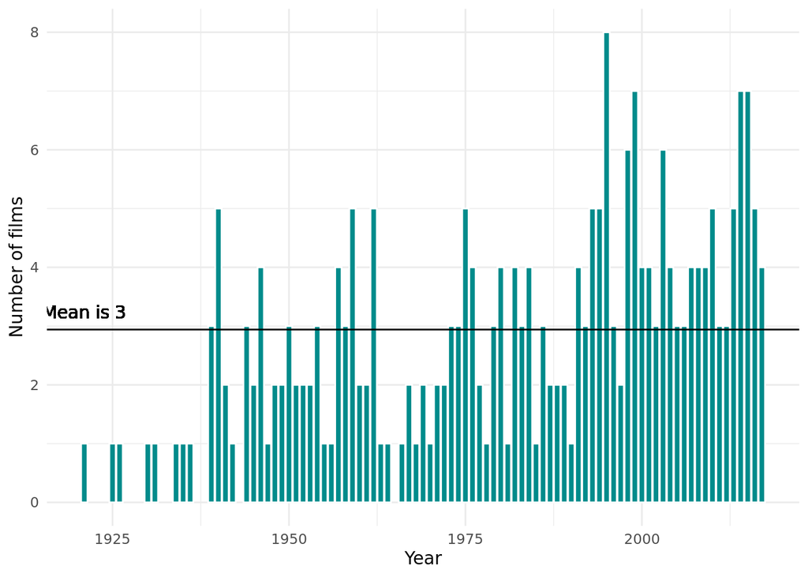

#### Task 9

Reproduce! ;)

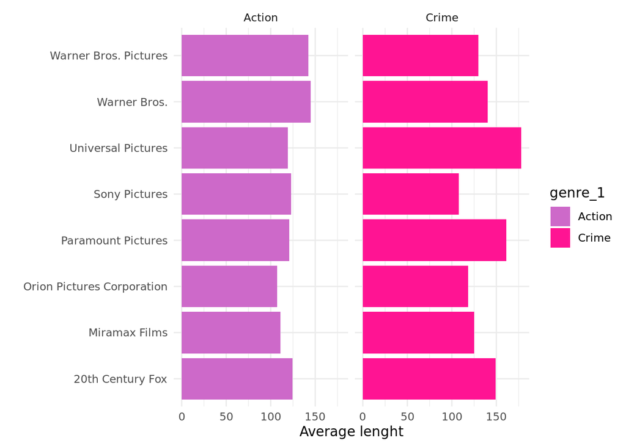